# Rational Pricing: The Black-Scholes Model

## 1. No-arbitrage fixes the forward value

The chapter assumes no transaction costs, the same constant continuously compounded rate $r$ for borrowing and lending, and unrestricted long and short positions. Consider a contract that obliges its holder to buy one share at time $T$ for the delivery price $K$. Its terminal payoff is

$$ S_T-K. $$

One share together with a loan of $Ke^{-rT}$ has the same payoff: the share is worth $S_T$, and the loan requires repayment of $K$. The no-arbitrage value of the contract at time $0$ is therefore

$$ V_0^{\mathrm{fwd}}=S_0-Ke^{-rT}. $$

This is the current value of a contract with delivery price $K$. If a new forward is required to have zero initial value, its delivery price must instead satisfy

$$ K^{\ast}=S_0e^{rT}. $$

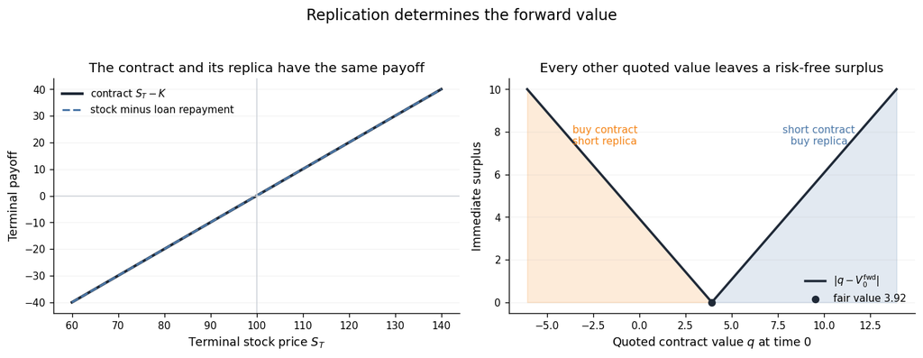

**Figure 1.** Terminal payoffs of a forward contract and its stock-loan replica, together with the risk-free initial surplus produced by a quoted value $q$ different from $V_0^{\mathrm{fwd}}$. Here $S_0=100$, $K=100$, $r=0.04$, and $T=1$.

Interpretation. The coincident lines in the left panel establish the payoff identity for every displayed $S_T$. In the right panel, overpricing calls for buying the replica and shorting the contract, while underpricing reverses the positions. The surplus is zero only at $S_0-Ke^{-rT}$, so the price is fixed by replication without assigning probabilities to future stock prices.

## 2. Put-call parity is a payoff identity

A European call gives the right to buy one share at time $T$ for $K$; a European put gives the right to sell it. Let $C_0$ and $P_0$ be their time-$0$ prices. Compare a call plus a bond paying $K$ with one share plus a put:

| Terminal state | Call plus bond | Stock plus put |
| --- | --- | --- |
| *S*<sub>T</sub> ≤ *K* | 0 + *K* = *K* | *S*<sub>T</sub> + (*K* − *S*<sub>T</sub>) = *K* |
| *S*<sub>T</sub> > *K* | (*S*<sub>T</sub> − *K*) + *K* = *S*<sub>T</sub> | *S*<sub>T</sub> + 0 = *S*<sub>T</sub> |

Both portfolios pay $\max(S_T,K)$ in every state. The no-arbitrage principle therefore gives

$$ C_0+Ke^{-rT}=S_0+P_0, $$

or equivalently

$$ C_0-P_0=S_0-Ke^{-rT}. $$

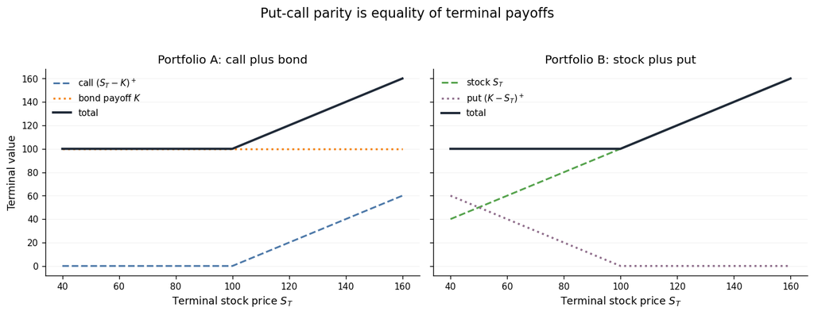

**Figure 2.** Component and total terminal values of the call-bond and stock-put portfolios for strike $K=100$.

Interpretation. The components differ, but each black total equals $K$ when $S_T\leq K$ and $S_T$ when $S_T>K$. Equal payoffs under the chapter's trading assumptions require equal initial costs, which yields put-call parity. The payoff table supplies the exact state-by-state argument; the curves display the same identity across terminal stock prices.

## 3. Replication in a one-period market

Example 7.3 considers a contingent claim $H$, denoted $F$ in the notes, in a market with dates $0$ and $1$. The stock and bond begin at

$$ S_0=2, \qquad \beta_0=1, $$

and the interest rate is zero. At time $1$, the stock is either $1$ or $4$, while the claim pays $0$ or $3$ respectively. A portfolio with $a$ shares and $b$ bonds must satisfy

$$ a+b=0, \qquad 4a+b=3. $$

Hence $a=1$ and $b=-1$. Its initial value, and therefore the claim's no-arbitrage price, is

$$ H_0=aS_0+b\beta_0=2-1=1. $$

No state probabilities enter this calculation because the two equations match both possible payoffs exactly.

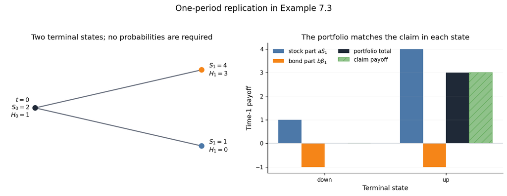

**Figure 3.** The two stock states in Example 7.3 and the terminal contributions of the replicating holdings $a=1$ and $b=-1$.

Interpretation. In the down state, the stock contributes $1$ and the short bond contributes $-1$, giving the claim payoff $0$. In the up state, the same fixed holdings give $4-1=3$. Because one portfolio matches both states, its time-$0$ cost $2-1=1$ is the unique no-arbitrage value of the claim.

## 4. Self-financing replication gives the PDE

For the continuous-time model, take $S_0>0$, $\sigma>0$, a horizon $T>0$, and a strike $K>0$. The stock follows geometric Brownian motion and the bank account grows at rate $r$:

$$ dS_t=\mu S_t\,dt+\sigma S_t\,dB_t, \qquad d\beta_t=r\beta_t\,dt, \qquad \beta_0=1. $$

The positive sign gives $\beta_t=e^{rt}$ and is consistent with the subsequent calculation in the lecture notes. A portfolio with value

$$ V_t=a(t)S_t+b(t)\beta_t $$

is self-financing when

$$ dV_t=a(t)\,dS_t+b(t)\,d\beta_t. $$

Assume that the call value has the form $V_t=f(t,S_t)$, where $f$ is $C^{1,2}$ for $0\leq t<T$ and $x>0$. Itô's formula gives

$$ df(t,S_t) =\left(\partial_t f+\mu S_t\partial_x f +\frac12\sigma^2S_t^2\partial_{xx}f\right)dt +\sigma S_t\partial_xf\,dB_t. $$

The self-financing equation gives

$$ dV_t =\left(a(t)\mu S_t+r b(t)\beta_t\right)dt +a(t)\sigma S_t\,dB_t. $$

Matching the $dB_t$ coefficients yields $a(t)=\partial_xf(t,S_t)$. The value identity then gives

$$ b(t)\beta_t=f(t,S_t)-S_t\partial_xf(t,S_t). $$

Substitution into the drift equation cancels the term containing $\mu$ and yields the Black-Scholes PDE

$$ \partial_t f(t,x) +\frac12\sigma^2x^2\partial_{xx}f(t,x) +rx\partial_xf(t,x)-rf(t,x)=0, \qquad 0\leq t<T, \quad x>0, $$

with terminal condition

$$ f(T,x)=(x-K)^+. $$

This derivation does not divide by $r$, so it also covers the case $r=0$.

## 5. The Black-Scholes price and delta

Let $\tau=T-t>0$ and let $\Phi$ be the standard normal distribution function. Define

$$ d_1(t,x) =\frac{\log(x/K)+(r+\frac12\sigma^2)\tau} {\sigma\sqrt{\tau}}, \qquad d_2(t,x)=d_1(t,x)-\sigma\sqrt{\tau}. $$

The solution given in Chapter 7 is

$$ f(t,x)=x\Phi(d_1(t,x))-Ke^{-r\tau}\Phi(d_2(t,x)). $$

The stock holding in the replicating portfolio is the delta

$$ a(t)=\partial_xf(t,S_t)=\Phi(d_1(t,S_t)), $$

while the value held in the bank account is

$$ b(t)\beta_t=f(t,S_t)-a(t)S_t =-Ke^{-r\tau}\Phi(d_2(t,S_t)). $$

At $t=T$, the value is read from the terminal condition $f(T,x)=(x-K)^+$ rather than from $d_1$ and $d_2$, whose denominators contain $\sqrt{T-t}$.

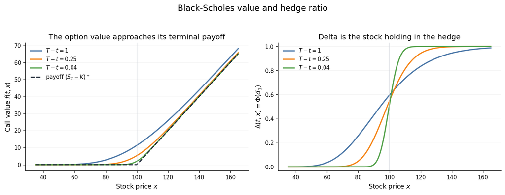

**Figure 4.** Black-Scholes call values and deltas against the stock price for $K=100$, $r=0.03$, $\sigma=0.25$, and three times to maturity.

Interpretation. The price curves approach the kinked payoff as maturity approaches. Delta lies between $0$ and $1$: it is near $0$ when exercise is far out of the money and near $1$ when exercise is far in the money. The transition becomes sharper near $K$ as $T-t$ decreases, linking the price slope directly to the number of shares in the continuous replicating portfolio.

## 6. Continuous replication and discrete rebalancing

The model's replicating strategy updates $a(t)=\Delta(t,S_t)$ continuously. A numerical strategy can trade only at finitely many times. Starting from the exact Black-Scholes value, it holds the current delta between grid points and places the remaining value in the bank account. For $N$ rebalancing intervals, define the terminal hedging error by

$$ E_N=V_T^{(N)}-(S_T-K)^+. $$

The experiment below simulates geometric Brownian motion exactly at the trading times. Its drift $\mu$ determines the simulated stock-path distribution, while the pricing formula and delta use only $r$ and $\sigma$, as predicted by the PDE derivation.

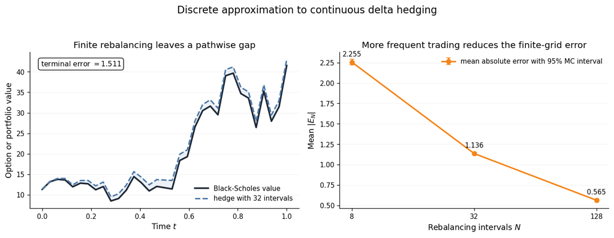

**Figure 5.** A 32-interval delta hedge on one simulated path and mean absolute terminal errors for $N=8,32,128$, using 12,000 common GBM paths with $S_0=K=100$, $\mu=0.08$, $r=0.03$, $\sigma=0.25$, and $T=1$. Vertical bars are approximate pointwise 95% Monte Carlo intervals for the estimated means.

Interpretation. The left panel follows the option value closely, but the terminal difference remains nonzero because delta is held fixed between trading times. In the right panel, mean absolute error decreases as the grid is refined. The vertical bars quantify Monte Carlo uncertainty at each frequency; the movement across frequencies records the discretisation effect. Continuous self-financing replication supplies the zero-error model benchmark, while this experiment measures its finite-trading approximation.